# W8：取樣理論與中央極限定理——化混亂為秩序

心理教育統計 2026

授課教師：陳紹慶 | e-mail: csc2009@mail.tcu.edu.tw

2026/04/20

# 本週學習目標

**理解概念**：

1. 區分「母群」與「樣本」、「參數」與「統計量」
2. 區分「樣本分佈」與「取樣分佈」
3. 理解中央極限定理（CLT）的奧義

**數學工具**：

1. 標準誤（SE）的計算與意義：$SE = \frac{SD}{\sqrt{N}}$
2. 樣本數 N 對精確度的影響

**軟體操作**：

1. 解讀jamovi 報表 S.E. Mean 的數值意義

## 對應教材

- 《用 jamovi 上手統計學》
  - [第 8 章：運用樣本估計未知量數](https://scgeeker.github.io/lsj-book-zh_tw/08-Estimating-unknown-quantities-from-a-sample.html)（8.1-8.3）

**簡報示範資料**：課堂 jamovi模擬測試 + `IQsim.omv`

**作業資料**：個人化 CLT 模擬資料（`W08_CLT_Simulation_[學號].csv`）

# Part 1：上帝視角 vs. 人類視角🧠

## 回顧：你的 W4 資料從哪裡來？

還記得 W4 的 100 筆資料嗎？

- 你清理了 Age 異常值、統一了 Gender 編碼
- 你反向計分 Q3，計算了 Total_Score
- W5/W6 你分析了 Total_Score 的描述統計和圖表
- W7 你檢驗了 Total_Score 是否符合常態分佈

**關鍵問題**：這 100 筆資料是「全部的真相」嗎？

## 喝湯的譬喻

**母群（Population）** = 整鍋湯

- 包含所有可能的觀測值
- 通常**不可能**全部測量
- 有「真實的」參數：$\mu$, $\sigma$

**樣本（Sample）** = 喝一口

- 從母群中選取的**部分**資料
- 我們實際能觀察到的
- 計算出的是「統計量」：$\bar{X}$, $s$

> **這一口鹹，整鍋湯就一定鹹嗎？**

不一定！這就是**取樣誤差**。

每次喝一口，鹹度都不太一樣。

但如果你喝了**很多口**，平均起來就會**越來越接近整鍋湯的真實味道**。

## 你的 100 筆資料來自 10,000 人母群

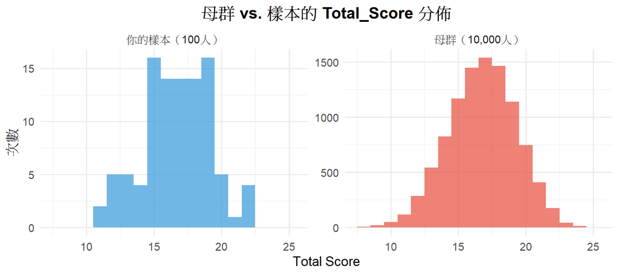

> 你的母群也是客製化的！

## 參數 vs. 統計量

|  | 母群（Population） | 樣本（Sample） |
| --- | --- | --- |
| **符號** | 希臘字母 | 拉丁字母 |
| **平均數** | $\mu$（mu） | $\bar{X}$（X bar） |
| **標準差** | $\sigma$（sigma） | $s$ |
| **大小** | $N$（通常很大或無限） | $n$（我們收集到的） |
| **性質** | **固定但未知** | **已知但會變動** |

> 統計學的核心任務：用**已知的樣本統計量**推測**未知的母群參數**

## 取樣方法

**簡單隨機取樣**：母群中每個成員被選中的機率相等

- 就像從一袋球中隨機抽取
- 這是統計推論的理論基礎

> “簡單”永遠是最困難的方法

## 取樣方法(續)

**現實中的問題**：

- 方便取樣（convenience sampling）：只調查身邊的人
- 自願者偏誤：只有有興趣的人回答
- 資格限制：只能取得特定群體資料

> **好的取樣**決定統計推論的品質

# Part 2：大數法則——越多越準🧠

## 大數法則（Law of Large Numbers）

**直覺理解**：

- 擲骰子 10 次，平均值可能偏離 3.5 很多
- 擲骰子 10,000 次，平均值幾乎就是 3.5

**數學表述**：

$$\text{當 } n \to \infty \text{ 時，}
\bar{X} \to \mu$$

## 大數法則的視覺化

[interactive chart not shown]

# Part 3：中央極限定理——統計學的魔法🧠

## 從一個實驗說起

想像你做了以下實驗：

1. 從母群隨機抽 **5 個人**，計算他們的平均數 → 記錄下來
2. 放回去，再抽 **5 個人**，計算平均數 → 再記錄
3. 重複 **1,000 次**

你會得到 **1,000 個平均數**。

**問題**：這 1,000 個平均數會排成什麼形狀？

## 先看 RT_ms：一個明顯偏態的變項

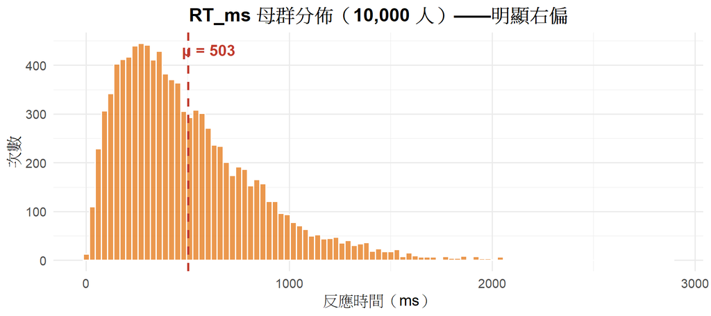

**偏態係數**：1.4（遠離 0 = 明顯偏態）

## CLT 魔法：偏態變常態！

[interactive chart not shown]

## 中央極限定理（CLT）三大重點

無論母群的分佈形狀如何，當樣本數 $N$ 足夠大：

1. **取樣分佈的平均數** = 母群平均數 $\mu$
2. **取樣分佈的標準差** = $\frac{\sigma}{\sqrt{N}}$（就是**標準誤 SE**）
3. **取樣分佈的形狀**趨近**常態分佈**

> **CLT 是統計推論的基石**：它告訴我們，不管母群長什麼樣子，只要 N 夠大，就可以預測每一次的 $\bar{X}$ 。

## 樣本分佈 vs. 取樣分佈

**樣本分佈**（Sample Distribution）

- **一組樣本的測量資料**怎麼分佈
- 例如：你的 100 筆 Total_Score
- 特徵：Mean, SD, 可能偏態
- 分析資料實際處理的
- 有必要檢測符合**理論分佈**的條件

**取樣分佈**（Sampling Distribution）

- **很多組平均數**怎麼分佈
- 例如：1,000 次取樣的 1,000 個 $\bar{X}$
- 特徵：趨近常態、寬度 = $SE = \frac{\sigma}{\sqrt{N}}$
- 理論的，分析資料是要估計取樣分佈的**參數**

以上是最需要區分的觀念！混淆這兩者是學習中央極限定理最常見的障礙。

# Part 4：標準誤——測量精確度的量尺🧠👨‍💻

## SD vs. SE：兩個容易混淆的指標

**標準差（SD）**

- 衡量**資料點**之間的分散程度
- 反映「個體差異」
- 公式：$SD = \sqrt{\frac{\sum(X_i - \bar{X})^2}{N-1}}$
- **不受樣本數影響**

**標準誤（SE）**

- 衡量**平均數估計值**的精確度
- 反映「取樣誤差」
- 公式：$SE = \frac{SD}{\sqrt{N}}$
- **N 越大，SE 越小**

## SE 公式的直覺理解

$$SE = \frac{SD}{\sqrt{N}}$$

**為什麼除以 $\sqrt{N}$？**

- 當你平均 $N$ 個獨立觀測值，每個人的隨機誤差會「互相抵消」
- 平均的效果：把噪音降低 $\sqrt{N}$ 倍
- $N = 100$ 時，$\sqrt{100} = 10$ → 精確度提升 10 倍

## 精確度競賽：N=5 vs. N=100

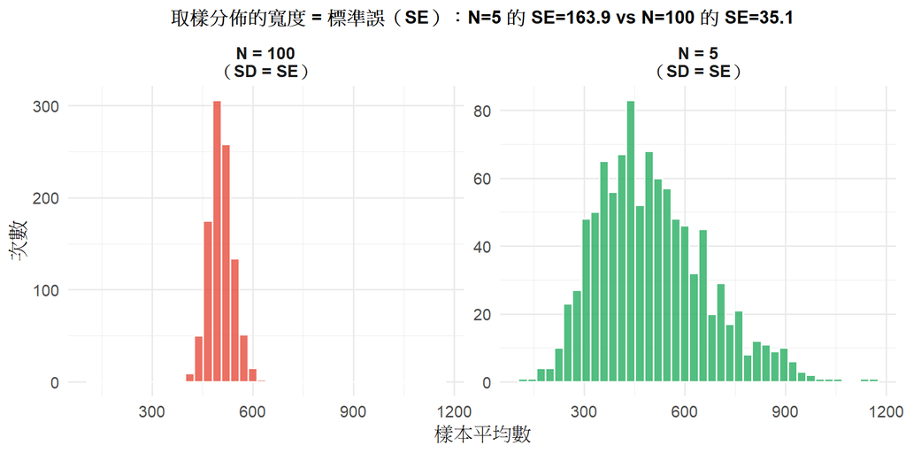

## SE 公式驗證

|  | 母群 SD | N | 理論 SE ($SD/\sqrt{N}$) | 實際 SE（模擬） |
| --- | --- | --- | --- | --- |
| N = 5 | 352.5 | 5 | 157.7 | 163.9 |
| N = 100 | 352.5 | 100 | 35.3 | 35.1 |

**比值驗證**：$\frac{SE_{N=100}}{SE_{N=5}} = \frac{\sqrt{5}}{\sqrt{100}} = 0.224$

實際比值：0.214

> 理論完美吻合！$N$ 越大，平均數的估計越精準。

## Total_Score 也一樣

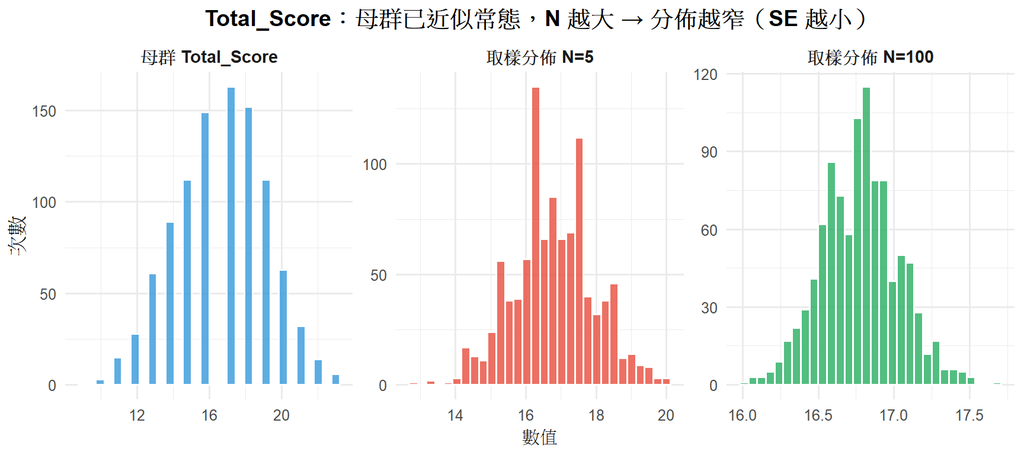

> 即使母群已經近似常態，增大 $N$ 仍然能顯著縮小 SE！

## 用jamovi 計算 S.E. Mean

**範例資料**： `IQ_sim.omv`

**展示調整**： 使用Filter指定一次處理的N

**操作步驟**：

1. Filter設定 `ROW()<=N` (N = 10逐步增加)
2. Exploration → Descriptives
3. 勾選 **Statistics** → ✓ S.E. Mean

## 用jamovi 計算 S.E. Mean (續)

**解讀**：

- S.E. Mean = $\frac{SD}{\sqrt{N}}$
- 這個數字告訴你：「你的平均數估計有多精準」
- S.E. 越小 → 平均數估計越可靠

> **注意**：母群的**標準誤**是沒有意義的（母群已經是「真理」，不需要估計）

## 為什麼 N 是科學研究的最強槓桿？

| N | $\sqrt{N}$ | SE = SD / $\sqrt{N}$ | 精確度倍數 |
| --- | --- | --- | --- |
| 5 | 2.24 | SD × 0.45 | 1× |
| 30 | 5.48 | SD × 0.18 | 2.4× |
| 100 | 10.00 | SD × 0.10 | 4.5× |
| 1000 | 31.62 | SD × 0.03 | 14.1× |

**啟示**：

- 從 N=5 到 N=30：精確度提升 **2.4 倍**（投資報酬率最高）
- 從 N=100 到 N=1000：精確度只再提升 **3 倍**（報酬遞減）

> 科學研究中，「增加樣本數」是提高研究品質最直接的方法

# Part 5：預告區間估計

## 從點估計到區間估計

**點估計**：$\bar{X} = 17.2$ → 這是我們對 $\mu$ 的最佳猜測

**問題**：我們有多大的信心？

**區間估計**：$17.2 \pm 2 \times SE$ → 我們有 95% 的信心，$\mu$ 在這個範圍內

**下週預告**：

- 為什麼是「95%」？
- 什麼是「信賴區間（CI）」？
- 為什麼小樣本需要「t 分佈」而不是「常態分佈」？

# Part 6：作業說明

## 本週作業：CLT 視覺化挑戰

**資料**：個人化 `W08_CLT_Simulation_[學號].csv`

你的資料包含 6 個變項（各 1,000 筆）：

| 變項 | 說明 |
| --- | --- |
| `Pop_RT` | RT_ms 母群代表樣本（偏態各異） |
| `Means_RT_N5` | RT_ms 取樣分佈（每次 N=5，1000次） |
| `Means_RT_N100` | RT_ms 取樣分佈（每次 N=100，1000次） |
| `Pop_Total` | Total_Score 母群代表樣本（偏態各異） |
| `Means_TS_N5` | Total_Score 取樣分佈（每次 N=5） |
| `Means_TS_N100` | Total_Score 取樣分佈（每次 N=100） |

## 任務 1：形狀對比（The Shape）

**操作**：

1. 匯入 CSV，設定所有變項為 **Continuous**
2. 使用 **Exploration → Descriptives** 繪製 6 個變項的直方圖
3. 勾選 **Statistics**：Mean, SD, Skewness

**診斷**：在報告中描述：

- `Pop_XX` vs. `Means_XX_N##` 的分佈形狀差異
- `Means_XX_N##`的分佈是否符合CLT ？你的判斷是什麼？

## 任務 2：精確度競賽（The Precision）

**計算**：

- 記錄 `Means_RT_N5` 和 `Means_RT_N100` 的 SD
- 記錄 `Means_TS_N5` 和 `Means_TS_N100` 的 SD

**驗證**：

$$\frac{SE_{N=100}}{SE_{N=5}} \approx
\frac{\sqrt{5}}{\sqrt{100}} \approx 0.224$$

你的實際比值是多少？與理論值吻合嗎？

## 任務 3：觀念辨析

在報告中回答以下問題：

1. **區分概念**：「樣本分佈」和「取樣分佈」有什麼不同？請用你檢視分佈狀態的方法說明。
2. **SE 的意義**：為什麼增加樣本數 $N$ 可以縮小標準誤？這對以RT或量表進行測量的科學研究有什麼啟示？
3. **CLT 的魔法**：為什麼即使母群是極端偏態的，樣本平均值累積的分佈卻接近常態分佈？請整合你從W08簡報裡的互動網頁學習心得。

## 繳交要求

**檔案 1：學號_姓名_W8_Lab.omv**

- 6 個變項的 Descriptives 分析（直方圖 + 統計量）
- 確認已勾選：Mean, SD, Skewness

**檔案 2：學號_姓名_W8_Report.docx**

- 分析結果：貼上直方圖與描述統計表，以APA格式說明圖表重點
- 計算驗證：SE 比值計算過程
- 反思問題：回答 3 題觀念問題

**繳交期限**：本週上課結束前

# 小結與展望

## 本週核心概念

1. **母群 vs. 樣本**：統計推論 = 用樣本推測母群
2. **大數法則**：N 越大，$\bar{X}$ 越接近 $\mu$
3. **中央極限定理**：無論母群形狀，$\bar{X}$ 的分佈趨近常態
4. **標準誤**：$SE = SD / \sqrt{N}$，衡量估計的精確度
5. **N 是最強槓桿**：增加樣本數 = 提高精確度

## 下週預告：信賴區間與 t 分佈

**下週問題**：

- 我們知道 SE 了，但 95% 信賴區間怎麼算？
- 為什麼小樣本不能用常態分佈，要用 **t 分佈**？
- **自由度（df）**是什麼？為什麼 $N - 1$？

**資料**：個人化 W9 取樣資料（N=5/30/100 三組樣本）

## 課後資源

**關鍵術語對照**：

| 中文 | 英文 | 符號 |
| --- | --- | --- |
| 母群 | Population | — |
| 樣本 | Sample | — |
| 母群平均數 | Population Mean | $\mu$ |
| 樣本平均數 | Sample Mean | $\bar{X}$ |
| 標準差 | Standard Deviation | $SD$ 或 $\sigma$ |
| 標準誤 | Standard Error | $SE$ 或 $SEM$ |
| 取樣分佈 | Sampling Distribution | — |
| 中央極限定理 | Central Limit Theorem | CLT |